# Linear Models – Transformations

Stat 241

## Quick Review

### Simple Linear Model

$$Y = \beta_0 + \beta_1 x + \varepsilon \qquad \mbox{where $\varepsilon \sim {\sf Norm}(0,\sigma)$.}$$

In other words

$$Y \sim {\sf Norm}(\beta_0 +\beta_1 x, \sigma)$$
### Diagnostics

We need to check the following things before relying on our model.

- **L**inear relationship
- **I**ndependent errors
- **N**ormal errors
- **E**qual standard deviation

## Linear Models for Non-linear relationships

Not all relationships are linear. For non-linear relationships, there are several approaches we can take.

1. Use a model with more than one predictor.
2. Use a model with a non-linear function.
3. Transform the variables to see if there is a linear relationship between the transformed variables.

Each of these is a useful approach for some problems. Here will talk about #3.

### Choosing a transformation

There are three reasons we might choose to use transformations:

1. To correspond to a theoretical model
2. To obtain a better fit
3. To improve residual behavior

We will look at some examples in a moment, but notice that all three of these are related. In particular, transformations affect both the fit and the residuals, and a transformation that improves fit might be harder to interpret than one that fits less well but corresponds to a theoretical model.

**Example: Estimating Planck’s Constant**

Sometimes we have *a priori* information that tells us what kind of non-linear relationship we should anticipate.  
For example, an experiment to estimate Planck’s constant ($\hbar$) using LED lights and a voltage meter is based on the relationship

$$V_a = \frac{\hbar c }{e \lambda} + k$$

We can design an experiment that measures $V_a$ and $\lambda$ for a number of different colors.

A little algebra gives us

$$V_a = \frac{\hbar c }{e} \cdot \frac{1}{\lambda} + k$$

So if we fit a model with

- $V_a$ as the response, and
- $\frac{1}{\lambda}$ as the predictor,

then

- intercept = $k$
- slope = $\frac{\hbar c}{e}$
  - We can use this to solve for $\hbar$:

  $$\hbar = \beta_1 \frac{e}{c}$$
  - If we have uncertainties for $c$ and $e$, we can use propagation of uncertainty to get an uncertainty for $\hbar$. (The regression model will give us an uncertainty for $\beta_1$.)

Theory says that a scatter plot of $V_a$ and $1/\lambda$ should form a straight line, so the the model we would fit would look something like

```r
lm(voltage ~ I(1/wavelength), data = mydata)
```

Some things to notice

- We need to wrap `1/lambda` in `I()` because the arithmetic symbols `+`, `-`, `*`, `/`, and `^` have special meanings inside the formula for a model. `I()` stands for *inhibit* special interpretation.
- The intercept is not directly involved in estimating $\hbar$, but that we can’t fit the line and obtain our slope without it.

Many other relationships can be transformed to linear. Common transformation functions are the reciprocal and logarithm functions.

## Three Important Laws

Three types of relationships (often called “laws”) occur so often in science that they are worth mentioning. Each is also easily transformed into a linear relationship.

### Log-log and semi-log plots

We can check whether a power or exponential law appears to hold by creating a plot of log(y) vs log(x) (log-log plot) or of log(y) vs x (semi-log plot).

**Synthetic Example: Power Law**

Let’s simulate data that follows a power law.

```r
SynthData <- tibble(
  x = 1:10,
  y = 3 * x^1.8
)
```

Now we can make some plots to investigate. The log-log plot should be linear.

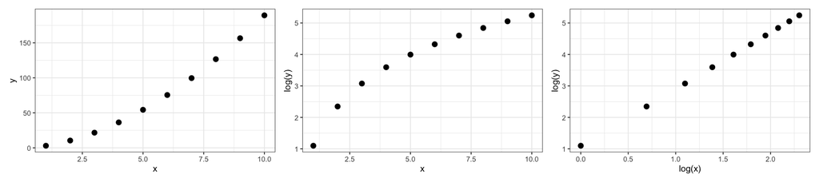

```r
gf_point(y ~ x, data = SynthData) |
gf_point(log(y) ~ x, data = SynthData) |
gf_point(log(y) ~ log(x), data = SynthData)
```

If want to retain the natural units in our plots, we can transform the scales rather than transforming the data.

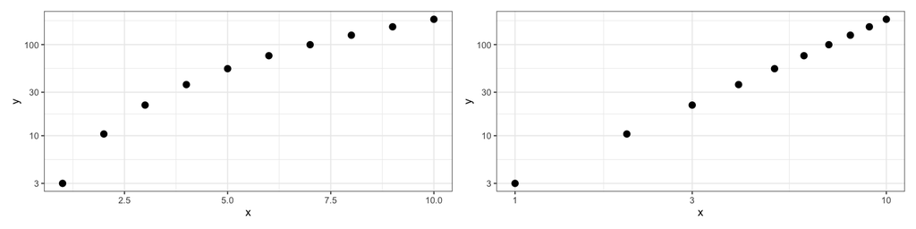

```r
gf_point(y ~ x, data = SynthData) %>%
  gf_refine(scale_y_log10()) |
gf_point(y ~ x, data = SynthData) %>%
  gf_refine(scale_y_log10(), scale_x_log10())
```

Real data won’t fit perfectly like this synthetic data, of course.

## Tukey’s Ladder of Re-expression

Section 8.7.3 in the [Notes](https://rpruim.github.io/Engineering-Statistics/book/Stat241-Notes.pdf#page=187) describes a method for narrowing down our search for a transformation just based on the shape of the relationship in our data.

## More Examples

**Example: Dropping balls**

**Good fit?**

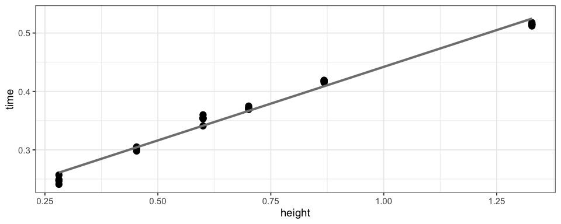

```r
library(fastR2)
gf_point(time ~ height, data = BallDrop) %>% gf_lm(color = "gray50")
```

```r
ball.model <- lm(time ~ height, data = BallDrop)
msummary(ball.model)
```

```
##             Estimate Std. Error t value Pr(>|t|)
## (Intercept)  0.19024    0.00430    44.2   <2e-16 ***
## height       0.25184    0.00552    45.7   <2e-16 ***
##
## Residual standard error: 0.0101 on 28 degrees of freedom
## Multiple R-squared:  0.987,  Adjusted R-squared:  0.986
## F-statistic: 2.08e+03 on 1 and 28 DF,  p-value: <2e-16
```

**Notes on $R^2$**

- Labeled “Multiple R-squared” in the summary output.
- Square of correlation coefficient.
- Commonly used metric of “fit”, but it has some issues.
  - Good: $R^2 = \frac{SSE}{SST}$ = proportion of variation in response explained by the model.
  - Bad: Good fits can have small $R^2$, bad fits can have large $R^2$, so it isn’t useful in isolation.

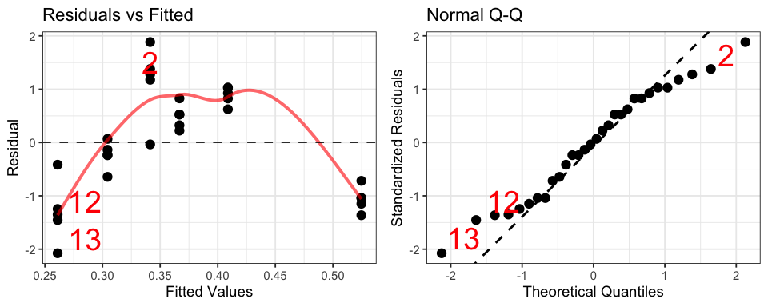

```r
mplot(ball.model, w = 1:2) %>% cowplot::plot_grid(plotlist = ., nrow = 1)
```

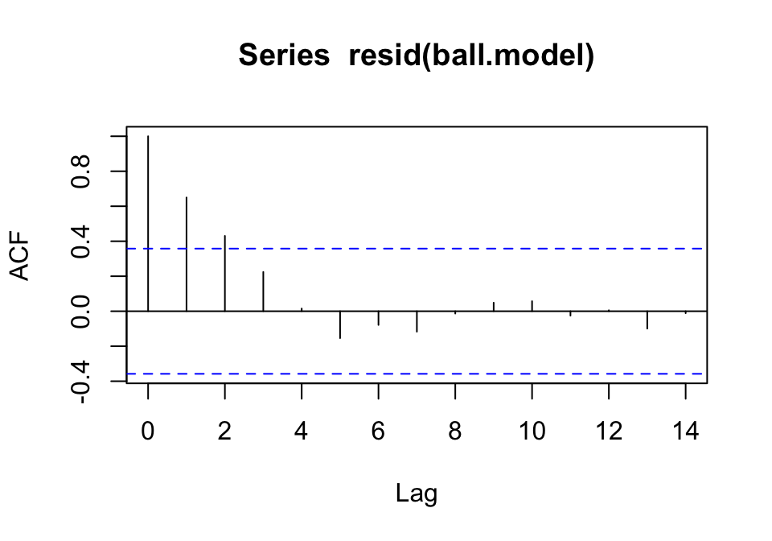

```r
acf(resid(ball.model))
```

What sort of transformations should we try?

- Second quadrant of Tukey’s bulge
- So down for `heigth` or up for `time`.
- Let’s try `sqrt(height)` since we don’t need a particularly strong transformation.

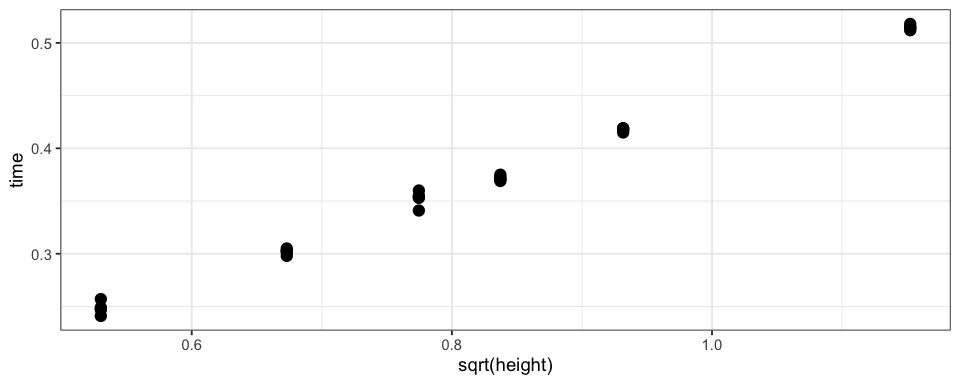

```r
ball.model2 <- lm(time ~ sqrt(height), data = BallDrop)
gf_point(time ~ sqrt(height), data = BallDrop)
```

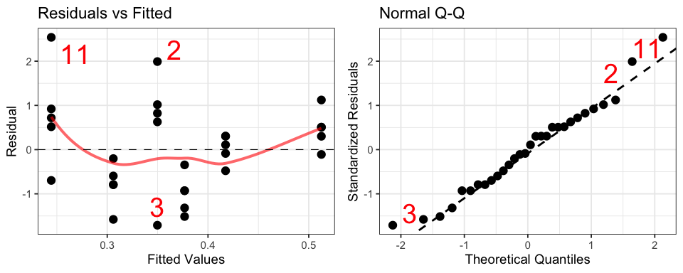

```r
mplot(ball.model2, which = 1:2) %>% cowplot::plot_grid(plotlist = ., nrow = 1)
```

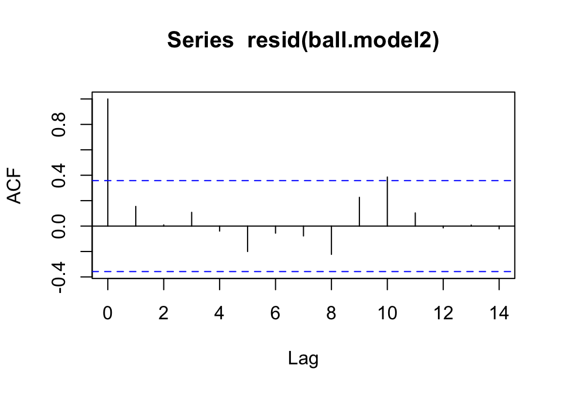

```r
acf(resid(ball.model2))
```

Everything looks better, but there is still one problem. Can you spot it? (See the [Notes](https://rpruim.github.io/Engineering-Statistics/book/Stat241-Notes.pdf#page=190) for more discussion.)

**Example: Concentration**

A chemical engineering text book suggest a law of the form
$$\log\left( - \frac{dC}{dt} \right) = \log(k) + \alpha \log(C)$$
where $C$ is concentration and $t$ is time.

This is equivalent to
$$\begin{align*}
- \frac{dC}{dt} &= k \cdot C^\alpha
\\
- \int C^{-\alpha} \; dC &= \int k \;dt
\\
- \frac{1}{1-\alpha} C^{1-\alpha} &= k t + d
\\
\frac{1}{\beta} C^{-\beta} & = k t + d
\\
C^{-\beta} & = \beta k t + \beta d
\end{align*}$$

If we know $\beta = \alpha - 1$ (i.e., if we know $\alpha$), then we can fit a linear model using

```r
lm(C^(-1/beta) ~ t)
```

The intercept of such a model will be $\beta d$ and the slope will be $\beta k$, from which we can easily recover $d$ and $k$.

Alternatively, if we know $d = 0$ (i.e., if we know that $C = 0$ when $t = 0$), then we can use
$$\begin{align*}
\log( C^{-\beta} ) = -\beta \log(C) &= \log(\beta k t ) = \log(\beta k) + \log t
\\
\log(C) &= - \frac{\log(\beta k)}{\beta} - \frac{1}{\beta} \log t
\end{align*}$$

Now if we fit a model of the form

```r
lm(C ~ log(t))
```

the intercept will be $\frac{-\log(\beta k)}{\beta}$ and the slope will be $\frac{-1}{\beta}$. From this we can solve for $k$ and $\beta$.

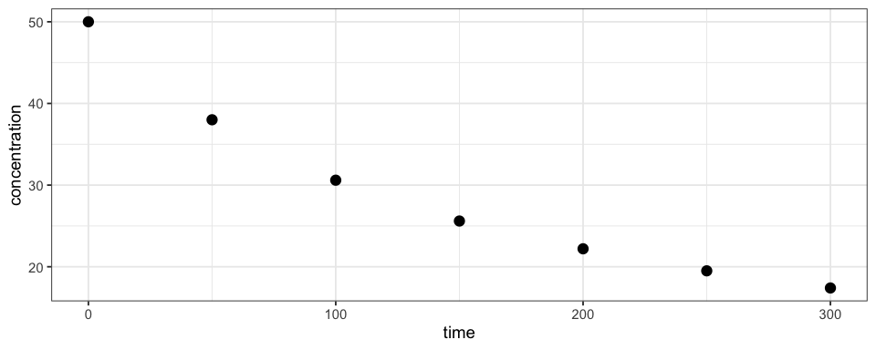

```r
Concentration <- data.frame(
  time = c(0, 50, 100, 150, 200, 250, 300),               # minutes
  concentration = c(50, 38, 30.6, 25.6, 22.2, 19.5, 17.4) # mol/dm^3 * 10^3
)
gf_point(concentration ~ time, data = Concentration)
```

Under the assumption that $\alpha = 2$, so $\beta = 1$, our relationship becomes
$$\frac{1}{C} = - k t - d \;.$$
We can now fit a model and see how well it does.

```r
conc.model <- lm(1/concentration ~ time, data = Concentration)
summary(conc.model)
```

```
##
## Call:
## lm(formula = 1/concentration ~ time, data = Concentration)
##
## Residuals:
##         1         2         3         4         5         6         7
## -1.18e-04 -4.14e-05  8.28e-05  2.26e-04 -3.13e-05 -3.40e-05 -8.45e-05
##
## Coefficients:
##             Estimate Std. Error t value Pr(>|t|)
## (Intercept) 2.01e-02   8.76e-05     230  3.0e-11 ***
## time        1.25e-04   4.86e-07     257  1.7e-11 ***
## ---
## Signif. codes:  0 '***' 0.001 '**' 0.01 '*' 0.05 '.' 0.1 ' ' 1
##
## Residual standard error: 0.000129 on 5 degrees of freedom
## Multiple R-squared:     1,   Adjusted R-squared:     1
## F-statistic: 6.59e+04 on 1 and 5 DF,  p-value: 1.7e-11
```

```r
confint(conc.model)
```

```
##                2.5 %   97.5 %
## (Intercept) 0.019892 0.020343
## time        0.000124 0.000126
```

This provides estimates for the intercept $- \beta d$ and the slope $- \beta k$ of our model. We can divide by $-\beta$ to obtain estimates for $d$ and $k$.

Of course, we should always look to see whether the fit is a good fit.

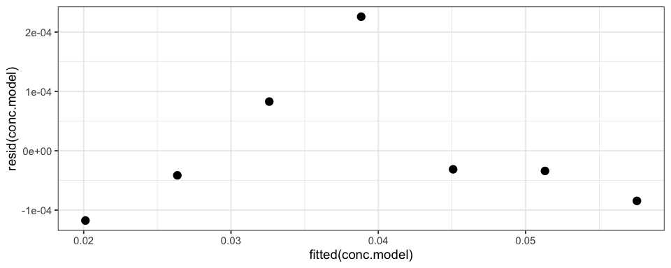

```r
gf_point(resid(conc.model) ~ fitted(conc.model))
```

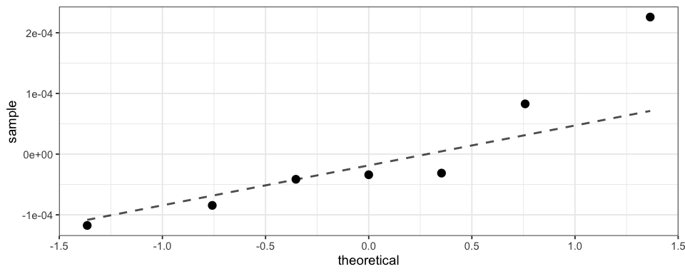

```r
gf_qq(~resid(conc.model)) %>% gf_qqline()
```

Notice that these residuals are very small relative to the values for concentration. (We can see this from the vertical scale of the plot and also from the small value for residual standard error in the summary output.) The shape of the residual plot would be more disturbing if the magnitudes were larger and if there were more data.  
As is, even if there is some systematic problem, it is roughly five orders of magnitude smaller than our concentration measurements, which likely can’t be measured to that degree of accuracy.

If we want to show the fit on top of the original data, we must remember to back-transform the response, since the model we fitted is a model for $1/C$, but we want to show a model for $C$. Here’s how to do that with `gf_lm()`. Notice that we need to specify both `formula` and `backtrans`.

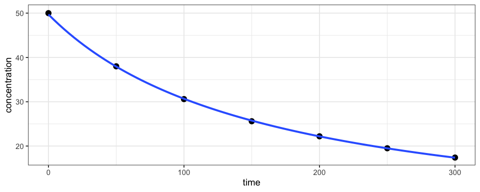

```r
gf_point( concentration ~ time, data = Concentration ) %>%
  gf_lm(
    formula = I(1/y) ~ x,
    backtrans = makeFun(1/y ~ y)
  )
```

## Some Practice

**1.** Redo the synthetic example with some noise in the data.

```r
sigma <- 10
SynthData <- tibble(
  x = 1:10,
  y = 3 * x^1.8 + rnorm(10, 0, sigma)
)
```

1. Plot the new synthetic data on the natural scale and also make log-log and semi-log plots.
2. Try making `sigma` larger or smaller and repeating. You should see that the smaller that number is, the easier it is to distinguish the form of the relationship.

You can make up similar examples to see how things work with other relationship forms.

**2.** For each of the following relationships between a response $y$ and an explanatory variable $x$, if possible find a pair of transformations $f$ and $g$ so that $g(y)$ is a linear function of $f(x)$:
$$g(y) = \beta_0 + \beta_1 f(x) \;.$$
and identify how $\beta_0$ and $\beta_1$ are related to the relationship.

If $y = a e^{bx}$, then $\log(y) = \log(a) + bx$, so $g(y) = \log(y)$, $f(x) = x$, $\beta_0= \log(a)$, and $\beta_1 = b$.

1. $y = a b^x$.
2. $y = a x^b$.
3. $y = \frac{1}{a + bx}$.
4. $y = \frac{x}{a + bx}$.
5. $y = a x^2 + b x + c$.
6. $\displaystyle y = \frac{1}{1+e^{a+bx}}$.
7. $\displaystyle y = \frac{100}{1+e^{a+bx}}$.

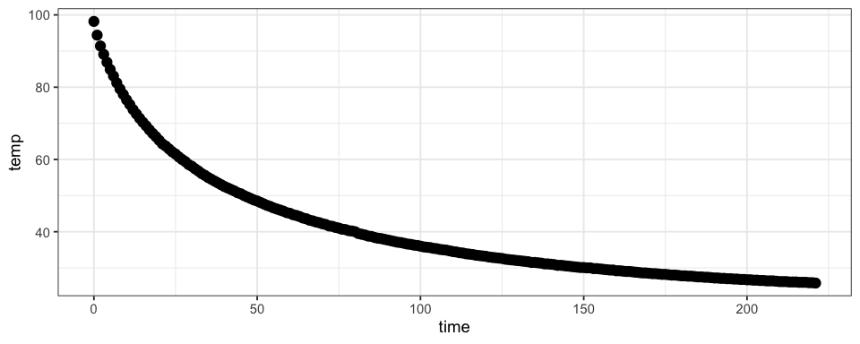

```r
gf_point(temp ~ time, data = CoolingWater)
```

Use Tukey’s bulge to try some transformations. Can you find a good one? Make some scatter plots to see.

If you find a good one,

- Write down the transformation
- Write down the algebraic equation (with $\beta_0$ and $\beta_1$) for the model. Does it “back-transform” to anything nice?
- Fit the model with `lm()` and check our diagnostic plots to see how well it works.

If none of them are good, see if you can come up with a reason why.

**4.** By attaching a heavy object to the end of a string, it is easy to construct pendulums of different lengths. Some physics students did this to see how the period (time in seconds until a pendulum returns to the same location moving in the same direction) depends on the length (in meters) of the pendulum.  
The students constructed pendulums of lengths varying from $10$ cm to $16$ m and recorded the period length (averaged over several swings of the pendulum). The resulting data are in the `Pendulum` data set in the `fastR2` package.

Fit a power law to this data using a transformation and a linear model.

1. How well does the power law fit?
2. What is the estimated power in the power law based on this model?

**5.** The `Pressure` data set in the `fastR2` package contains data on the relation between temperature in degrees Celsius and vapor pressure in millimeters (of mercury). With temperature as the predictor and pressure as the response, use transformations as needed to obtain a good fit. Make a list of all the models you considered and explain how you chose your best model. What does your model say about the relationship between pressure and temperature?

**6.** In the absence of air resistance, a dropped object will continue to accelerate as it falls. But if there is air resistance, the situation is different. The drag force due to air resistance depends on the velocity of an object and operates in the opposite direction of motion. Thus as the object’s velocity increases, so does the drag force until it eventually equals the force due to gravity. At this point the net force is $0$ and the object ceases to accelerate, remaining at a constant velocity called the terminal velocity.

Now consider the following experiment to determine how terminal velocity depends on the mass (and therefore on the downward force of gravity) of the falling object. A helium balloon is rigged with a small basket and just the right ballast to make it neutrally buoyant. Mass is then added and the terminal velocity is calculated by measuring the time it takes to fall between two sensors once terminal velocity has been reached.

The `Drag` data set (in the `fastR2` package) contains the results of such an experiment conducted by some undergraduate physics students.  
Mass is measured in grams and velocity in meters per second.  
(The distance between the two sensors used for determining terminal velocity is given in the `height` variable.)

By fitting models to this data, determine which of the following “drag laws” matches the data best:

1. Drag is proportional to velocity.
2. Drag is proportional to the square of velocity.
3. Drag is proportional to the square root of velocity.
4. Drag is proportional to the logarithm of velocity.